# tratamento colinearidade

## Estudo de Caso: Tratamento de Supressão e Colinearidade Extrema em Modelos Comportamentais

Este exemplo se baseia no tratamento de um caso real com dados obtidos a partir de uma pesquisa de mercado sobre migração de marca. Os dados foram obtidos de coleta via painel com $N=500$ respondentes, estruturada sob o framework metodológico PPM (Push-Pull-Mooring). Para respeitar a confidencialidade dos dados e do cliente, os nomes das variáveis foram descaracterizados e a ponderação amostral adotada no estudo base foi descartada para este exemplo de portfólio.

### 1. O Framework Teórico: Push-Pull-Mooring (PPM)

A migração de marca é estruturada sob o modelo comportamental de escolha discreta de **Bansal et al. (2005)**, particionado em três pilares fundamentais:

- **Push (Dores / Fatores de Expulsão):** Aversão, problemas de hardware, lentidão, suporte e frustrações acumuladas com o equipamento atual.
- **Pull (Atratividade da Concorrência):** Apelo de design, ecossistema, inovação e percepção de superioridade das marcas concorrentes.
- **Mooring (Amarras / Barreiras de Saída):** Inércia psicológica, custo financeiro de transição, curva de aprendizado e dependência de periféricos.

### 2. O Problema Encontrado Durante a Análise

No caso prático, após a coleta, limpeza e adequação dos dados para análise, verificamos que as variáveis abordadas no estudo eram naturalmente todas intrinsecamente ligadas. Isso levou a dois problemas:

1. **O Colapso do Push:** Quando o modelo hierárquico clássico adiciona a percepção de atratividade da concorrência (Pull), o efeito das dores do produto atual (Push) **perde totalmente a significância estatística e inverte seu sinal**, sugerindo erroneamente que ter defeitos no produto tornaria o cliente mais fiel à marca.
2. **O Paradoxo do VIF Baixo:** O diagnóstico usual de colinearidade via *Variance Inflation Factor* encontra valores baixos ($\text{VIF} < 2{,}1$), gerando a falsa premissa de que os preditores são ortogonais e descartando o Push prematuramente.

Este notebook documenta o diagnóstico econométrico dessa patologia (Supressão Clássica) e aplica uma **Análise de Importância Relativa via Decomposição de Shapley do $\text{Pseudo-}R^2$ de McFadden combinada à Regressão Logística Binária Hierárquica em Blocos Controlada por Covariáveis** para resgatar a força explicativa real de cada dimensão.

```python
import pandas as pd
import numpy as np

# 1. Carregamento da base analítica anonimizada
df = pd.read_csv('dados_ppm_portfolio.csv')

print("=" * 85)
print(f"📦 BASE ANALÍTICA: {df.shape[0]} respondentes x {df.shape[1]} variáveis")
print("=" * 85)

# 2. Distribuição do Desfecho (Variável Dependente - Y)
n_total = len(df)
n_fiel = (df['Y_estagio1'] == 0).sum()
n_vuln = (df['Y_estagio1'] == 1).sum()

print("🎯 DESFECHO BINÁRIO (Y_estagio1):")
print(f"  • 0 = Fiel à Marca Atual:      {n_fiel:3d} ({n_fiel/n_total*100:.1f}%)")
print(f"  • 1 = Vulnerável a Mudar:      {n_vuln:3d} ({n_vuln/n_total*100:.1f}%)")
print(f"  • Total da Amostra:            {n_total:3d} (100.0%)")

# 3. Mapeamento das Variáveis Efetivamente Utilizadas na Modelagem
controle_vars = ['idade_anos', 'renda_nivel', 'tempo_posse_meses']
macro_vars = ['z_Push_Global', 'z_Pull_Percepcao', 'z_Mooring']
itens_push = [f'fator_push_{l}' for l in ['A', 'B', 'C', 'D', 'E', 'F', 'G', 'H', 'I', 'J', 'K', 'L']]
itens_pull = [f'fator_pull_{l}' for l in ['A', 'B', 'C', 'D']]
itens_mooring = [f'fator_mooring_{l}' for l in ['A', 'B', 'C', 'D']]

todas_vars = (
    [('Controle Demográfico', v) for v in controle_vars] +
    [('Pilar Macro (Z-Score)', v) for v in macro_vars] +
    [('PUSH (Dores 1-5)', v) for v in itens_push] +
    [('PULL (Atração 1-5)', v) for v in itens_pull] +
    [('MOORING (Barreiras 1-5)', v) for v in itens_mooring]
)

# 4. Tabela de Tendência Central e Dispersão
tabela_desc = []
for bloco, v in todas_vars:
    s = df[v]
    tabela_desc.append({
        'Bloco Analítico': bloco,
        'Variável': v,
        'Média': f"{s.mean():.2f}",
        'DP': f"{s.std():.2f}",
        'Mín': f"{s.min():.1f}",
        'Mediana': f"{s.median():.1f}",
        'Máx': f"{s.max():.1f}"
    })

df_desc = pd.DataFrame(tabela_desc)

print("\n" + "=" * 85)
print("📊 MEDIDAS DE TENDÊNCIA CENTRAL E DISPERSÃO DAS VARIÁVEIS ANALÍTICAS")
print("=" * 85)
print(df_desc.to_string(index=False))
```

```
=====================================================================================
📦 BASE ANALÍTICA: 500 respondentes x 42 variáveis
=====================================================================================
🎯 DESFECHO BINÁRIO (Y_estagio1):
  • 0 = Fiel à Marca Atual:      147 (29.4%)
  • 1 = Vulnerável a Mudar:      353 (70.6%)
  • Total da Amostra:            500 (100.0%)

=====================================================================================
📊 MEDIDAS DE TENDÊNCIA CENTRAL E DISPERSÃO DAS VARIÁVEIS ANALÍTICAS
=====================================================================================
        Bloco Analítico          Variável Média    DP  Mín Mediana  Máx
   Controle Demográfico        idade_anos 37.68  9.42 27.0    33.0 60.5
   Controle Demográfico       renda_nivel  2.32  0.95  1.0     2.5  4.0
   Controle Demográfico tempo_posse_meses 29.09 20.93  3.0    18.0 72.0
  Pilar Macro (Z-Score)     z_Push_Global  0.00  1.00 -1.1    -0.3  2.9
  Pilar Macro (Z-Score)  z_Pull_Percepcao  0.00  1.00 -1.3     0.0  1.7
  Pilar Macro (Z-Score)         z_Mooring  0.00  1.00 -1.2    -0.2  2.3
       PUSH (Dores 1-5)      fator_push_A  2.81  1.41  1.0     3.0  5.0
       PUSH (Dores 1-5)      fator_push_B  2.83  1.47  1.0     3.0  5.0
       PUSH (Dores 1-5)      fator_push_C  2.17  1.35  1.0     2.0  5.0
       PUSH (Dores 1-5)      fator_push_D  2.47  1.36  1.0     2.0  5.0
       PUSH (Dores 1-5)      fator_push_E  2.58  1.46  1.0     2.0  5.0
       PUSH (Dores 1-5)      fator_push_F  2.12  1.30  1.0     2.0  5.0
       PUSH (Dores 1-5)      fator_push_G  1.94  1.27  1.0     1.0  5.0
       PUSH (Dores 1-5)      fator_push_H  1.92  1.22  1.0     1.0  5.0
       PUSH (Dores 1-5)      fator_push_I  1.94  1.20  1.0     1.0  5.0
       PUSH (Dores 1-5)      fator_push_J  1.81  1.24  1.0     1.0  5.0
       PUSH (Dores 1-5)      fator_push_K  2.02  1.22  1.0     1.5  5.0
       PUSH (Dores 1-5)      fator_push_L  1.90  1.23  1.0     1.0  5.0
     PULL (Atração 1-5)      fator_pull_A  2.99  1.49  1.0     3.0  5.0
     PULL (Atração 1-5)      fator_pull_B  2.83  1.47  1.0     3.0  5.0
     PULL (Atração 1-5)      fator_pull_C  2.55  1.46  1.0     3.0  5.0
     PULL (Atração 1-5)      fator_pull_D  2.63  1.55  1.0     3.0  5.0
MOORING (Barreiras 1-5)   fator_mooring_A  2.28  1.48  1.0     1.0  5.0
MOORING (Barreiras 1-5)   fator_mooring_B  2.13  1.41  1.0     1.0  5.0
MOORING (Barreiras 1-5)   fator_mooring_C  2.70  1.52  1.0     3.0  5.0
MOORING (Barreiras 1-5)   fator_mooring_D  2.65  1.47  1.0     3.0  5.0
```

```python
import pandas as pd
import numpy as np
import statsmodels.api as sm
from sklearn.metrics import roc_auc_score

# 1. Carregar base anonimizada
df = pd.read_csv('dados_ppm_portfolio.csv')

# 2. Função para ajuste de bloco logístico
def rodar_bloco_logit(pred_list, label_modelo):
    y = df['Y_estagio1']
    X = sm.add_constant(df[pred_list])
    n = len(y)

    mod_null = sm.Logit(y, np.ones((n, 1))).fit(disp=False)
    mod = sm.Logit(y, X).fit(disp=False)

    # Métricas de Ajuste
    ll_null, ll_mod = mod_null.llf, mod.llf
    mcfadden = 1.0 - (ll_mod / ll_null)
    cs = 1.0 - np.exp((2.0 / n) * (ll_null - ll_mod))
    max_cs = 1.0 - np.exp((2.0 / n) * ll_null)
    nagelkerke = cs / max_cs
    auc = roc_auc_score(y, mod.predict(X))

    linhas = []
    for var in pred_list:
        coef = mod.params[var]
        se = mod.bse[var]
        pval = mod.pvalues[var]
        sig = '***' if pval < 0.001 else ('**' if pval < 0.01 else ('*' if pval < 0.05 else ('.' if pval < 0.1 else 'ns')))
        linhas.append({
            'Modelo': label_modelo,
            'Preditor': var,
            'Beta': round(coef, 3),
            'SE': round(se, 3),
            'p-valor': round(pval, 4),
            'Sig': sig,
            'Odds Ratio (OR)': round(np.exp(coef), 2),
            'IC 95%': f"[{np.exp(mod.conf_int().loc[var, 0]):.2f} - {np.exp(mod.conf_int().loc[var, 1]):.2f}]"
        })

    fit = {
        'Modelo': label_modelo,
        'Log-Lik': round(ll_mod, 2),
        'Nagelkerke R²': f"{nagelkerke*100:.1f}%",
        'McFadden R²': f"{mcfadden*100:.1f}%",
        'AUC-ROC': round(auc, 3),
        'AIC': round(mod.aic, 1)
    }
    return pd.DataFrame(linhas), fit

# 3. Modelos aninhados progressivos
m1_preds = ['z_Push_Global', 'z_idade', 'z_renda', 'z_tempo_posse']
m2_preds = ['z_Push_Global', 'z_Mooring', 'z_idade', 'z_renda', 'z_tempo_posse']
m3_preds = ['z_Push_Global', 'z_Pull_Percepcao', 'z_Mooring', 'z_idade', 'z_renda', 'z_tempo_posse']

c1, f1 = rodar_bloco_logit(m1_preds, 'Modelo 1: PUSH + Controles')
c2, f2 = rodar_bloco_logit(m2_preds, 'Modelo 2: PUSH + MOORING + Controles')
c3, f3 = rodar_bloco_logit(m3_preds, 'Modelo 3: PUSH + MOORING + PULL (Completo)')

print("="*95)
print("📊 PASSO 1: COMPARAÇÃO DE AJUSTE DOS MODELOS HIERÁRQUICOS (N=500)")
print("="*95)
print(pd.DataFrame([f1, f2, f3]).to_string(index=False))

print("\n" + "="*95)
print("📈 PASSO 2: COEFICIENTES E ODDS RATIOS (EVIDÊNCIA DA SUPRESSÃO DO PUSH)")
print("="*95)
print(pd.concat([c1, c2, c3], ignore_index=True).to_string(index=False))
```

```
===============================================================================================
📊 PASSO 1: COMPARAÇÃO DE AJUSTE DOS MODELOS HIERÁRQUICOS (N=500)
===============================================================================================
                                    Modelo  Log-Lik Nagelkerke R² McFadden R²  AUC-ROC   AIC
                Modelo 1: PUSH + Controles  -292.62          5.7%        3.4%    0.624 595.2
      Modelo 2: PUSH + MOORING + Controles  -275.64         14.7%        9.0%    0.700 563.3
Modelo 3: PUSH + MOORING + PULL (Completo)  -245.34         29.3%       19.0%    0.788 504.7

===============================================================================================
📈 PASSO 2: COEFICIENTES E ODDS RATIOS (EVIDÊNCIA DA SUPRESSÃO DO PUSH)
===============================================================================================
                                    Modelo         Preditor   Beta    SE  p-valor Sig  Odds Ratio (OR)        IC 95%
                Modelo 1: PUSH + Controles    z_Push_Global  0.288 0.110   0.0090  **             1.33 [1.07 - 1.65]
                Modelo 1: PUSH + Controles          z_idade -0.276 0.118   0.0196   *             0.76 [0.60 - 0.96]
                Modelo 1: PUSH + Controles          z_renda  0.115 0.121   0.3413  ns             1.12 [0.89 - 1.42]
                Modelo 1: PUSH + Controles    z_tempo_posse  0.229 0.107   0.0320   *             1.26 [1.02 - 1.55]
      Modelo 2: PUSH + MOORING + Controles    z_Push_Global  0.594 0.129   0.0000 ***             1.81 [1.41 - 2.33]
      Modelo 2: PUSH + MOORING + Controles        z_Mooring -0.666 0.120   0.0000 ***             0.51 [0.41 - 0.65]
      Modelo 2: PUSH + MOORING + Controles          z_idade -0.268 0.123   0.0296   *             0.76 [0.60 - 0.97]
      Modelo 2: PUSH + MOORING + Controles          z_renda  0.123 0.125   0.3225  ns             1.13 [0.89 - 1.44]
      Modelo 2: PUSH + MOORING + Controles    z_tempo_posse  0.240 0.111   0.0310   *             1.27 [1.02 - 1.58]
Modelo 3: PUSH + MOORING + PULL (Completo)    z_Push_Global -0.155 0.169   0.3612  ns             0.86 [0.61 - 1.19]
Modelo 3: PUSH + MOORING + PULL (Completo) z_Pull_Percepcao  1.268 0.182   0.0000 ***             3.55 [2.49 - 5.08]
Modelo 3: PUSH + MOORING + PULL (Completo)        z_Mooring -0.933 0.143   0.0000 ***             0.39 [0.30 - 0.52]
Modelo 3: PUSH + MOORING + PULL (Completo)          z_idade -0.258 0.134   0.0540   .             0.77 [0.59 - 1.00]
Modelo 3: PUSH + MOORING + PULL (Completo)          z_renda  0.101 0.132   0.4434  ns             1.11 [0.85 - 1.43]
Modelo 3: PUSH + MOORING + PULL (Completo)    z_tempo_posse  0.312 0.121   0.0101   *             1.37 [1.08 - 1.73]
```

A abordagem classica de literatura para modelos PPM é a análise através de uma Regressão Estrutural Hierárquica em Dois Estágios, onde no primeiro estágio os itens são agrupados em fatores latentes de segunda ordem (push, pull e mooring)

1. **Comparativo entre modelos 1 e 2:** Quando os fatores são controlados por mooring (fatores de inércia e custo de troca) o efeito do push (as dores fruto da experiência com o produto) saltam de $OR = 1{,}33$ ($p = 0{,}009$) para $OR = 1{,}81$ ($p < 0{,}001$). Isso ocorre porque as barreiras de saída camuflam a expressão direta do descontentamento do usuário.
2. **Comparativo entre modelos 2 e 3:** A inclusão da percepção de pull (atratividade externa da concorrencia), $OR = 3{,}55, (p < 0{,}001$) colapsa o regressor de push para $OR = 0{,}86$ ($p = 0{,}361$), tornando-o estatisticamente nulo e invertendo seu sinal, como se ter problemas no produto posse um fator que leva o usuário a manter a marca.
3. **Implicação Prática:** Em uma análise tradicional, o Push seria descartado por falta de significância. No entanto, conforme demonstrado a seguir, essa anulação é fruto da sobreposição informacional ($r = 0{,}689$), e impossibilita uma análise diagnóstica sobre as causas da migração de marca exigindo técnicas de **Decomposição de Shapley (Análise de dominância)** para que se possa verificar o peso causal real de cada regressor

```python
import pandas as pd
import statsmodels.api as sm
from statsmodels.stats.outliers_influence import variance_inflation_factor

# 1. Matriz de Correlação de Postos de Spearman
print("="*95)
print("📌 DIAGNÓSTICO 1: MATRIZ DE CORRELAÇÃO DE SPEARMAN (Preditores vs. Desfecho)")
print("="*95)
cols_corr = ['Y_estagio1', 'z_Push_Global', 'z_Pull_Percepcao', 'z_Mooring', 'z_idade', 'z_renda', 'z_tempo_posse']
matriz_spearman = df[cols_corr].corr(method='spearman').round(3)
print(matriz_spearman.to_string())

# 2. Diagnóstico de VIF
print("\n" + "="*95)
print("📌 DIAGNÓSTICO 2: VARIANCE INFLATION FACTOR (PARADOXO DO VIF BAIXO)")
print("="*95)
X_vif = sm.add_constant(df[['z_Push_Global', 'z_Pull_Percepcao', 'z_Mooring', 'z_idade', 'z_renda', 'z_tempo_posse']])
vif_data = pd.DataFrame({
    'Variável': X_vif.columns[1:],
    'VIF': [variance_inflation_factor(X_vif.values, i) for i in range(1, X_vif.shape[1])]
}).round(2)
print(vif_data.to_string(index=False))
```

```
===============================================================================================
📌 DIAGNÓSTICO 1: MATRIZ DE CORRELAÇÃO DE SPEARMAN (Preditores vs. Desfecho)
===============================================================================================
                  Y_estagio1  z_Push_Global  z_Pull_Percepcao  z_Mooring  z_idade  z_renda  z_tempo_posse
Y_estagio1             1.000          0.208             0.312     -0.176   -0.103   -0.043          0.094
z_Push_Global          0.208          1.000             0.689      0.349   -0.225   -0.152          0.100
z_Pull_Percepcao       0.312          0.689             1.000      0.324   -0.145   -0.062          0.006
z_Mooring             -0.176          0.349             0.324      1.000   -0.026   -0.007          0.037
z_idade               -0.103         -0.225            -0.145     -0.026    1.000    0.577          0.078
z_renda               -0.043         -0.152            -0.062     -0.007    0.577    1.000         -0.090
z_tempo_posse          0.094          0.100             0.006      0.037    0.078   -0.090          1.000

===============================================================================================
📌 DIAGNÓSTICO 2: VARIANCE INFLATION FACTOR (PARADOXO DO VIF BAIXO)
===============================================================================================
        Variável  VIF
   z_Push_Global 2.04
z_Pull_Percepcao 1.90
       z_Mooring 1.20
         z_idade 1.49
         z_renda 1.43
   z_tempo_posse 1.04
```

Aqui, mesmo que tenhamos constatado semanticamente que a analise de regressão classica não faz sentido e verifiquemos que existe uma correlação fortissima (em termos comportamentais, r=0,69 significa variáveis super-hyper ligadas) e que a variável de barreiras (Mooring) tinha correlação negativa com a escolha final ($r = -0{,}18$), mas correlação positiva com os outros preditores ($r \approx 0{,}33$), o fator de inflação da variância encontra um valor plenamente aceitável (<2.1 para todos os preditores).

Existe um problema clássico onde a absorção de variância é causada, não pela inflação na matriz de covariância dos estimadores (VCOV), o que seria detectado pelo VIF, mas sim por fatores que englobam a variável dependente, causados pela relação triangular entre Push, Pull, e o desfecho (intenção de troca ou não de marca).

Para comprovar esse efeito, executamos testes formais de deslocamento de parâmetros e supressão clássica (Conger; Clogg et al.).

```python
import numpy as np
import pandas as pd
import statsmodels.api as sm
from scipy import stats

# ==============================================================================
# DIAGNÓSTICO AVANÇADO DE SUPRESSÃO ESTATÍSTICA (Além do VIF)
# ==============================================================================

# 1. TESTE ANALÍTICO DE SUPRESSÃO DE CONGER (1974)
r_y_push = df['Y_estagio1'].corr(df['z_Push_Global'])
r_y_pull = df['Y_estagio1'].corr(df['z_Pull_Percepcao'])
r_push_pull = df['z_Push_Global'].corr(df['z_Pull_Percepcao'])

produto_indireto = r_y_pull * r_push_pull
diferenca_conger = r_y_push - produto_indireto

print("="*95)
print("📌 TESTE 1: CRITÉRIO MATEMÁTICO DE SUPRESSÃO CLÁSSICA (Conger, 1974)")
print("="*95)
print(f"• r(Y, Push)                            = {r_y_push:.4f}")
print(f"• r(Y, Pull) * r(Push, Pull)            = {produto_indireto:.4f}")
print(f"• Diferença [r(Y,Push) - Produto]       = {diferenca_conger:.4f}")



# 1. Preditoras dos Modelos 2 e 3
m2_preds = ['z_Push_Global', 'z_Mooring', 'z_idade', 'z_renda', 'z_tempo_posse']
m3_preds = [
    'z_Push_Global',
    'z_Pull_Percepcao',
    'z_Mooring',
    'z_idade',
    'z_renda',
    'z_tempo_posse',
]
# 2. Delta Beta Observado na amostra completa (N=500)
X2_full = sm.add_constant(df[m2_preds])
X3_full = sm.add_constant(df[m3_preds])
y_full = df['Y_estagio1']
b2_obs = sm.Logit(y_full, X2_full).fit(disp=False).params['z_Push_Global']
b3_obs = sm.Logit(y_full, X3_full).fit(disp=False).params['z_Push_Global']
delta_b = b2_obs - b3_obs
# 3. Bootstrap Não-Paramétrico Rápido (B = 1.000)
np.random.seed(42)
B = 1000
n = len(df)
y_arr = y_full.values
X2_arr = X2_full.values
X3_arr = X3_full.values
# Warm-start para rodar em ~1 segundo
start2 = sm.Logit(y_arr, X2_arr).fit(disp=False).params
start3 = sm.Logit(y_arr, X3_arr).fit(disp=False).params
delta_betas = []
for _ in range(B):
  idx = np.random.randint(0, n, n)
  m2 = sm.Logit(y_arr[idx], X2_arr[idx]).fit(
      start_params=start2, maxiter=25, disp=False
  )
  m3 = sm.Logit(y_arr[idx], X3_arr[idx]).fit(
      start_params=start3, maxiter=25, disp=False
  )
  delta_betas.append(m2.params[1] - m3.params[1])
delta_betas = np.array(delta_betas)
ic_low, ic_upp = np.percentile(delta_betas, [2.5, 97.5])
p_boot = np.mean(delta_betas <= 0) * 2
print('=' * 95)
print('📌 TESTE 2: TESTE DE COLAPSO VIA BOOTSTRAP NÃO-PARAMÉTRICO (B = 1.000)')
print('=' * 95)
print(f'• Delta Beta Observado (b_M2 - b_M3): {delta_b:.3f}')
print(f'• Intervalo de Confiança 95% (Boot):  [{ic_low:.3f} a {ic_upp:.3f}]')
print(f'• p-valor do Teste de Supressão:     {p_boot:.4e}')
print('=' * 95)
```

```
===============================================================================================
📌 TESTE 1: CRITÉRIO MATEMÁTICO DE SUPRESSÃO CLÁSSICA (Conger, 1974)
===============================================================================================
• r(Y, Push)                            = 0.1476
• r(Y, Pull) * r(Push, Pull)            = 0.2101
• Diferença [r(Y,Push) - Produto]       = -0.0626
===============================================================================================
📌 TESTE 2: TESTE DE COLAPSO VIA BOOTSTRAP NÃO-PARAMÉTRICO (B = 1.000)
===============================================================================================
• Delta Beta Observado (b_M2 - b_M3): 0.748
• Intervalo de Confiança 95% (Boot):  [0.561 a 1.007]
• p-valor do Teste de Supressão:     0.0000e+00
===============================================================================================
```

O teste de Conger comprovou a ocorrencia de **supressão clássica** entre as variáveis: como o produto das correlações excede a correlação direta [$r(Y, \text{Pull}) \times r(\text{Push}, \text{Pull}) > r(Y, \text{Push})$], a álgebra matricial da regressão força a inversão de sinal do $\beta$ do Push, independentemente do tamanho amostral.

Como o intervalo de confiança é estritamente positivo e distante de zero, fica formalmente comprovado que a inversão de sinal do Pushacontece por causa da da **sobreposição informacional estrutural** com o Pull ($r = 0{,}689$), e não de ausência de poder preditivo real.

Essa sobreposição não é erro de coleta, amostragem ou formulação da pesquisa. Naturalmente, quanto mais problemas e fatores de aversão ao produto da sua marca atual, o comportamento do ser humano é começar a supervalorizar as qualidades em concorrentes.

Para tratar dados com este perfil de sobreposição e colinearidade, adotamos a **Decomposição de Shapley sobre o Pseudo-$R^2$ de McFadden (Análise de Dominância)**. Em vez de forçar as variáveis a disputarem variância em uma única ordem de entrada arbitrária (onde o último a entrar é penalizado), este método calcula a contribuição marginal média de cada fator através de todos os $2^k$ subconjuntos de modelos possíveis ($2^3 = 8$ combinações para os três pilares), particionando o poder explicativo de forma cooperativa e restaurando a importância relativa real e positiva de cada dimensão a 100%.

```python
import math
import itertools
import pandas as pd
import numpy as np
import statsmodels.api as sm
from sklearn.metrics import roc_auc_score

# 1. Configuração dos pilares e controles
pilares = ['z_Push_Global', 'z_Pull_Percepcao', 'z_Mooring']
controles = ['z_idade', 'z_renda', 'z_tempo_posse']
y = df['Y_estagio1']
k = len(pilares)

# 2. Função para cálculo do McFadden R² para qualquer subconjunto
def calcular_mcfadden(vars_subset):
    cols = controles + list(vars_subset)
    X = sm.add_constant(df[cols])
    mod_null = sm.Logit(y, np.ones((len(y), 1))).fit(disp=False)
    mod = sm.Logit(y, X).fit(disp=False)
    return max(1.0 - (mod.llf / mod_null.llf), 0.0)

# 3. Avaliação dos 2^k submodelos possíveis
r2_dict = {}
for r in range(k + 1):
    for combo in itertools.combinations(pilares, r):
        r2_dict[frozenset(combo)] = calcular_mcfadden(combo) if len(combo) > 0 else calcular_mcfadden([])

# Exibir os submodelos avaliados
print("="*95)
print("🔍 SUBMODELOS AVALIADOS (2^3 = 8 Combinações de Predição)")
print("="*95)
for combo, r2_val in r2_dict.items():
    nomes = list(combo) if len(combo) > 0 else ['Apenas Controles']
    print(f"• Submodelo {nomes}: McFadden R² = {r2_val*100:.2f}%")

# 4. Cálculo da Contribuição Marginal Média de Shapley (LMG)
shapley_values = {p: 0.0 for p in pilares}
for p in pilares:
    outros = [x for x in pilares if x != p]
    for r in range(len(outros) + 1):
        peso = (math.factorial(r) * math.factorial(k - r - 1)) / math.factorial(k)
        for sub_combo in itertools.combinations(outros, r):
            s_set = frozenset(sub_combo)
            s_with_p = frozenset(list(sub_combo) + [p])
            marg_contrib = r2_dict[s_with_p] - r2_dict[s_set]
            shapley_values[p] += peso * max(marg_contrib, 0.0)

total_shapley = sum(shapley_values.values())
r2_total = r2_dict[frozenset(pilares)]

# 5. Cálculo das Métricas Globais de Ajuste e Discriminação (AUC-ROC e Nagelkerke)
cols_full = controles + pilares
X_full = sm.add_constant(df[cols_full])
n = len(y)
mod_null = sm.Logit(y, np.ones((n, 1))).fit(disp=False)
mod_full = sm.Logit(y, X_full).fit(disp=False)

ll_null, ll_full = mod_null.llf, mod_full.llf
cs = 1.0 - np.exp((2.0 / n) * (ll_null - ll_full))
max_cs = 1.0 - np.exp((2.0 / n) * ll_null)
nagelkerke = cs / max_cs
auc = roc_auc_score(y, mod_full.predict(X_full))

# 6. Tabela Final de Parts-Worth a 100%
tabela_shapley = pd.DataFrame([
    {
        'Pilar Teórico': 'Push (Dores / Fatores de Expulsão)',
        'Variável': 'z_Push_Global',
        'Contribuição Shapley': round(shapley_values['z_Push_Global'], 4),
        'Importância Relativa (Parts-Worth)': f"{(shapley_values['z_Push_Global'] / total_shapley)*100:.1f}%"
    },
    {
        'Pilar Teórico': 'Pull (Atratividade do Mercado)',
        'Variável': 'z_Pull_Percepcao',
        'Contribuição Shapley': round(shapley_values['z_Pull_Percepcao'], 4),
        'Importância Relativa (Parts-Worth)': f"{(shapley_values['z_Pull_Percepcao'] / total_shapley)*100:.1f}%"
    },
    {
        'Pilar Teórico': 'Mooring (Amarras / Inércia)',
        'Variável': 'z_Mooring',
        'Contribuição Shapley': round(shapley_values['z_Mooring'], 4),
        'Importância Relativa (Parts-Worth)': f"{(shapley_values['z_Mooring'] / total_shapley)*100:.1f}%"
    }
])

print("\n" + "="*95)
print("🏆 RESULTADO FINAL: DECOMPOSIÇÃO DE IMPORTÂNCIA RELATIVA A 100%")
print("="*95)
print(tabela_shapley.to_string(index=False))
print("-" * 95)
print(f"• McFadden Pseudo-R² Total:     {r2_total*100:.1f}% (Equivalente a R² de 70%-90% em OLS — McFadden, 1979)")
print(f"• Nagelkerke Pseudo-R²:         {nagelkerke*100:.1f}% (Variância explicada reescalonada)")
print(f"• AUC-ROC (Poder Discriminação): {auc:.3f} (Forte capacidade de separar fiéis vs. vulneráveis)")
print(f"• Soma das Contribuições:        100.0%")
print("="*95)
```

```
===============================================================================================
🔍 SUBMODELOS AVALIADOS (2^3 = 8 Combinações de Predição)
===============================================================================================
• Submodelo ['Apenas Controles']: McFadden R² = 2.18%
• Submodelo ['z_Push_Global']: McFadden R² = 3.38%
• Submodelo ['z_Pull_Percepcao']: McFadden R² = 9.46%
• Submodelo ['z_Mooring']: McFadden R² = 5.06%
• Submodelo ['z_Push_Global', 'z_Pull_Percepcao']: McFadden R² = 10.53%
• Submodelo ['z_Mooring', 'z_Push_Global']: McFadden R² = 8.98%
• Submodelo ['z_Mooring', 'z_Pull_Percepcao']: McFadden R² = 18.85%
• Submodelo ['z_Mooring', 'z_Push_Global', 'z_Pull_Percepcao']: McFadden R² = 18.99%

===============================================================================================
🏆 RESULTADO FINAL: DECOMPOSIÇÃO DE IMPORTÂNCIA RELATIVA A 100%
===============================================================================================
                     Pilar Teórico         Variável  Contribuição Shapley Importância Relativa (Parts-Worth)
Push (Dores / Fatores de Expulsão)    z_Push_Global                0.0128                               7.6%
    Pull (Atratividade do Mercado) z_Pull_Percepcao                0.0925                              55.0%
       Mooring (Amarras / Inércia)        z_Mooring                0.0628                              37.3%
-----------------------------------------------------------------------------------------------
• McFadden Pseudo-R² Total:     19.0% (Equivalente a R² de 70%-90% em OLS — McFadden, 1979)
• Nagelkerke Pseudo-R²:         29.3% (Variância explicada reescalonada)
• AUC-ROC (Poder Discriminação): 0.788 (Forte capacidade de separar fiéis vs. vulneráveis)
• Soma das Contribuições:        100.0%
===============================================================================================
```

A aplicação da decomposição de Shapley foi capaz de viabilizar a análise dos dados.

Ao contrário da regressão tradicional, a decomposição é capaz de captar o peso relativo da influência de cada fator sobre o todo. o ajuste foi considerado muito bom, com **AUC-ROC = 0,788** (capacidade de separar quem é fiel de quem é vulnerável em quase 80% das vezes) e **Nagelkerke $R^2 = 29,3\%$** (com McFadden de **19,0%**, considerado extremamente adequado para ajuste de modelos de escolha discreta).

Dentro do ajuste, os fatores de descontentamento com a marca atual correspondem a 7,6%, os fatores de atração da concorrentes respondem a 55% da decisão e a resistencia a mudança responde a 37,3%.

Como a variável resposta modela a vulnerabilidade/propensão à troca de marca, o fato de Pull (55,0%) e Mooring (37,3%) dominarem 92% da decisão enquanto Push tem apenas 7,6% significa que estar insatisfeito com a marca atual não é o gatilho principal da decisão imediata por outra marca no ato da troca. O cliente troca quando a concorrência é percebida como irresistível (Pull), desde que o custo de mudança (Mooring) não seja alto demais.

nota de análise: há sessões posteriores da mesma análise que vinculam fortemente os fatores de push com a criação de rejeição definitiva com a marca, eles apenas não são tão relevantes como causa proximal da decisaõ de marca.

Esses fatos possibilitam uma tomada de decisão mais precisa por parte do contratante, que pode inferir que os fatores determinantes de sucesso da marca se concentram na atração de novos clientes em vez da retenção.

Com o primeiro nível do modelo hierárquico resolvido de forma logicamente aceitável e ortogonal pela decomposição, avançamos para o segundo estágio da modelagem aninhada, onde os microfatores e atributos granulares de cada fator são avaliados via key driver analysis

```python
import pandas as pd
import numpy as np
import statsmodels.api as sm
from sklearn.preprocessing import StandardScaler

# 1. Configuração dos controles e desfecho
controles = ['z_idade', 'z_renda', 'z_tempo_posse']
y = df['Y_estagio1']

# Lista consolidada de todos os itens organizados por pilar
todos_itens = (
    [('PUSH (Dores)', f'fator_push_{l}') for l in ['A', 'B', 'C', 'D', 'E', 'F', 'G', 'H', 'I', 'J', 'K', 'L']] +
    [('PULL (Atratividade)', f'fator_pull_{l}') for l in ['A', 'B', 'C', 'D']] +
    [('MOORING (Barreiras)', f'fator_mooring_{l}') for l in ['A', 'B', 'C', 'D']]
)

# 2. Ajuste independente item a item (evita autocanibalização entre dores)
linhas_pedacos = []
for bloco, item in todos_itens:
    z_item = StandardScaler().fit_transform(df[[item]]).flatten()
    df_temp = df[controles].copy()
    df_temp['z_var'] = z_item

    X = sm.add_constant(df_temp)
    mod = sm.Logit(y, X).fit(disp=False)

    coef = mod.params['z_var']
    se = mod.bse['z_var']
    pval = mod.pvalues['z_var']
    or_val = np.exp(coef)
    ci_low = np.exp(mod.conf_int().loc['z_var', 0])
    ci_upp = np.exp(mod.conf_int().loc['z_var', 1])
    sig = '***' if pval < 0.001 else ('**' if pval < 0.01 else ('*' if pval < 0.05 else ('.' if pval < 0.1 else 'ns')))

    linhas_pedacos.append({
        'Pilar': bloco,
        'Item': item,
        'Beta': round(coef, 3),
        'SE': round(se, 3),
        'Odds Ratio (OR)': round(or_val, 2),
        'IC 95%': f"[{ci_low:.2f} - {ci_upp:.2f}]",
        'p-valor': round(pval, 4),
        'Sig': sig
    })

df_drivers = pd.DataFrame(linhas_pedacos)

print("="*100)
print("🎯 DRIVER ANALYSIS: ODDS RATIOS ISOLADOS E CONTROLADOS (N=500)")
print("="*100)
print(df_drivers.to_string(index=False))
print("-" * 100)
print("Legenda Sig: *** p<0.001 | ** p<0.01 | * p<0.05 | . p<0.1 | ns não significativo")
```

```
====================================================================================================
🎯 DRIVER ANALYSIS: ODDS RATIOS ISOLADOS E CONTROLADOS (N=500)
====================================================================================================
              Pilar            Item   Beta    SE  Odds Ratio (OR)        IC 95%  p-valor Sig
       PUSH (Dores)    fator_push_A  0.426 0.106             1.53 [1.24 - 1.88]   0.0001 ***
       PUSH (Dores)    fator_push_B  0.379 0.105             1.46 [1.19 - 1.80]   0.0003 ***
       PUSH (Dores)    fator_push_C  0.017 0.100             1.02 [0.84 - 1.24]   0.8675  ns
       PUSH (Dores)    fator_push_D  0.326 0.107             1.39 [1.12 - 1.71]   0.0024  **
       PUSH (Dores)    fator_push_E  0.333 0.109             1.40 [1.13 - 1.73]   0.0022  **
       PUSH (Dores)    fator_push_F  0.164 0.106             1.18 [0.96 - 1.45]   0.1211  ns
       PUSH (Dores)    fator_push_G  0.214 0.108             1.24 [1.00 - 1.53]   0.0474   *
       PUSH (Dores)    fator_push_H  0.104 0.104             1.11 [0.91 - 1.36]   0.3151  ns
       PUSH (Dores)    fator_push_I  0.133 0.106             1.14 [0.93 - 1.41]   0.2082  ns
       PUSH (Dores)    fator_push_J  0.114 0.105             1.12 [0.91 - 1.38]   0.2771  ns
       PUSH (Dores)    fator_push_K  0.327 0.112             1.39 [1.11 - 1.73]   0.0034  **
       PUSH (Dores)    fator_push_L  0.187 0.106             1.21 [0.98 - 1.48]   0.0785   .
PULL (Atratividade)    fator_pull_A  0.789 0.109             2.20 [1.78 - 2.72]   0.0000 ***
PULL (Atratividade)    fator_pull_B  0.581 0.105             1.79 [1.45 - 2.20]   0.0000 ***
PULL (Atratividade)    fator_pull_C  0.542 0.109             1.72 [1.39 - 2.13]   0.0000 ***
PULL (Atratividade)    fator_pull_D  0.560 0.108             1.75 [1.42 - 2.16]   0.0000 ***
MOORING (Barreiras) fator_mooring_A -0.138 0.100             0.87 [0.72 - 1.06]   0.1669  ns
MOORING (Barreiras) fator_mooring_B -0.357 0.099             0.70 [0.58 - 0.85]   0.0003 ***
MOORING (Barreiras) fator_mooring_C -0.439 0.104             0.64 [0.53 - 0.79]   0.0000 ***
MOORING (Barreiras) fator_mooring_D -0.424 0.104             0.65 [0.53 - 0.80]   0.0000 ***
----------------------------------------------------------------------------------------------------
Legenda Sig: *** p<0.001 | ** p<0.01 | * p<0.05 | . p<0.1 | ns não significativo
```

Da mesma forma que no primeiro nível, as variáveis micro também são relacionadas entre sí. Aqui adotamos a abordagem Key Driver Analysis com Modelos Bivariados Ajustados por Covariáveis. Cada atributo foi estimado de forma independente, controlando rigorosamente por idade, renda e tempo de posse, garantindo Odds Ratios limpos, estáveis e diretamente comparáveis.

Cada atributo granular foi estimado em regressões independentes, fixando o controle estatístico rigoroso pelas variáveis de perfil:

$$\text{logit}(P(Y=1)) = \alpha + \beta_k \cdot \text{Item}_k + \gamma_1 \cdot \text{Idade} + \gamma_2 \cdot \text{Renda} + \gamma_3 \cdot \text{Tempo de Posse}$$

Aqui os rótulos reais e análise sobre os microfatores está suprimida por respeito a acordo de confidencialidade sobre o produto e marca pesquisados, preservando-se integralmente a estrutura matemática, as covariâncias e a interpretabilidade dos estimadores.

```python
import numpy as np
import pandas as pd
from sklearn.preprocessing import StandardScaler
import statsmodels.api as sm

# 1. Configuração dos controles, desfecho e dominância macro (Estágio 1)
controles = ['z_idade', 'z_renda', 'z_tempo_posse']
y = df['Y_estagio1']

pesos_shapley = {
    'PUSH (Dores)': '7.6%',
    'PULL (Atratividade)': '55.0%',
    'MOORING (Barreiras)': '37.3%',
}

todos_itens = (
    [
        ('PUSH (Dores)', f'fator_push_{l}')
        for l in ['A', 'B', 'C', 'D', 'E', 'F', 'G', 'H', 'I', 'J', 'K', 'L']
    ]
    + [('PULL (Atratividade)', f'fator_pull_{l}') for l in ['A', 'B', 'C', 'D']]
    + [
        ('MOORING (Barreiras)', f'fator_mooring_{l}')
        for l in ['A', 'B', 'C', 'D']
    ]
)

# 2. Estimação Bivariada Controlada (Força Pura Descontaminada de Colinearidade)
linhas = []
for bloco, item in todos_itens:
  z_item = StandardScaler().fit_transform(df[[item]]).flatten()
  df_temp = df[controles].copy()
  df_temp['z_var'] = z_item

  X = sm.add_constant(df_temp)
  mod = sm.Logit(y, X).fit(disp=False)

  coef = mod.params['z_var']
  se = mod.bse['z_var']
  pval = mod.pvalues['z_var']
  or_val = np.exp(coef)
  ci_low = np.exp(mod.conf_int().loc['z_var', 0])
  ci_upp = np.exp(mod.conf_int().loc['z_var', 1])
  sig = (
      '***'
      if pval < 0.001
      else (
          '**'
          if pval < 0.01
          else ('*' if pval < 0.05 else ('.' if pval < 0.1 else 'ns'))
      )
  )

  # Interpretação probabilística precisa do Odds Ratio
  if sig == 'ns':
    interpretacao = 'Efeito Neutro / Não Significativo'
  elif or_val > 1.0:
    interpretacao = (
        f'+{(or_val - 1.0)*100:.1f}% Risco de Churn (Expulsão/Atração)'
    )
  else:
    interpretacao = f'{(or_val - 1.0)*100:.1f}% Proteção (Retenção/Inércia)'

  linhas.append({
      'Pilar Teórico': bloco,
      'Item': item,
      'Beta': round(coef, 3),
      'SE': round(se, 3),
      'Odds Ratio (OR)': round(or_val, 2),
      'IC 95%': f'[{ci_low:.2f} - {ci_upp:.2f}]',
      'p-valor': round(pval, 4),
      'Sig': sig,
      'Dominância Macro (Shapley)': pesos_shapley[bloco],
      'Impacto por +1 DP': interpretacao,
      'Forca_Abs': abs(coef),
  })

# Ordenar por magnitude de impacto absoluto
df_drivers = (
    pd.DataFrame(linhas)
    .sort_values(by='Forca_Abs', ascending=False)
    .drop(columns=['Forca_Abs'])
)

print('=' * 115)
print(
    '🎯 DRIVER ANALYSIS: FORÇA RELATIVA PURA CONTROLADA POR DEMOGRAFIA (N=500)'
)
print('=' * 115)
print(df_drivers.to_string(index=False))
print('-' * 115)
print(
    'Legenda Sig: *** p<0.001 | ** p<0.01 | * p<0.05 | . p<0.1 | ns não'
    ' significativo'
)
```

```
===================================================================================================================
🎯 DRIVER ANALYSIS: FORÇA RELATIVA PURA CONTROLADA POR DEMOGRAFIA (N=500)
===================================================================================================================
      Pilar Teórico            Item   Beta    SE  Odds Ratio (OR)        IC 95%  p-valor Sig Dominância Macro (Shapley)                         Impacto por +1 DP
PULL (Atratividade)    fator_pull_A  0.789 0.109             2.20 [1.78 - 2.72]   0.0000 ***                      55.0% +120.1% Risco de Churn (Expulsão/Atração)
PULL (Atratividade)    fator_pull_B  0.581 0.105             1.79 [1.45 - 2.20]   0.0000 ***                      55.0%  +78.8% Risco de Churn (Expulsão/Atração)
PULL (Atratividade)    fator_pull_D  0.560 0.108             1.75 [1.42 - 2.16]   0.0000 ***                      55.0%  +75.0% Risco de Churn (Expulsão/Atração)
PULL (Atratividade)    fator_pull_C  0.542 0.109             1.72 [1.39 - 2.13]   0.0000 ***                      55.0%  +72.0% Risco de Churn (Expulsão/Atração)
MOORING (Barreiras) fator_mooring_C -0.439 0.104             0.64 [0.53 - 0.79]   0.0000 ***                      37.3%        -35.5% Proteção (Retenção/Inércia)
       PUSH (Dores)    fator_push_A  0.426 0.106             1.53 [1.24 - 1.88]   0.0001 ***                       7.6%  +53.1% Risco de Churn (Expulsão/Atração)
MOORING (Barreiras) fator_mooring_D -0.424 0.104             0.65 [0.53 - 0.80]   0.0000 ***                      37.3%        -34.6% Proteção (Retenção/Inércia)
       PUSH (Dores)    fator_push_B  0.379 0.105             1.46 [1.19 - 1.80]   0.0003 ***                       7.6%  +46.0% Risco de Churn (Expulsão/Atração)
MOORING (Barreiras) fator_mooring_B -0.357 0.099             0.70 [0.58 - 0.85]   0.0003 ***                      37.3%        -30.0% Proteção (Retenção/Inércia)
       PUSH (Dores)    fator_push_E  0.333 0.109             1.40 [1.13 - 1.73]   0.0022  **                       7.6%  +39.6% Risco de Churn (Expulsão/Atração)
       PUSH (Dores)    fator_push_K  0.327 0.112             1.39 [1.11 - 1.73]   0.0034  **                       7.6%  +38.7% Risco de Churn (Expulsão/Atração)
       PUSH (Dores)    fator_push_D  0.326 0.107             1.39 [1.12 - 1.71]   0.0024  **                       7.6%  +38.5% Risco de Churn (Expulsão/Atração)
       PUSH (Dores)    fator_push_G  0.214 0.108             1.24 [1.00 - 1.53]   0.0474   *                       7.6%  +23.8% Risco de Churn (Expulsão/Atração)
       PUSH (Dores)    fator_push_L  0.187 0.106             1.21 [0.98 - 1.48]   0.0785   .                       7.6%  +20.6% Risco de Churn (Expulsão/Atração)
       PUSH (Dores)    fator_push_F  0.164 0.106             1.18 [0.96 - 1.45]   0.1211  ns                       7.6%         Efeito Neutro / Não Significativo
MOORING (Barreiras) fator_mooring_A -0.138 0.100             0.87 [0.72 - 1.06]   0.1669  ns                      37.3%         Efeito Neutro / Não Significativo
       PUSH (Dores)    fator_push_I  0.133 0.106             1.14 [0.93 - 1.41]   0.2082  ns                       7.6%         Efeito Neutro / Não Significativo
       PUSH (Dores)    fator_push_J  0.114 0.105             1.12 [0.91 - 1.38]   0.2771  ns                       7.6%         Efeito Neutro / Não Significativo
       PUSH (Dores)    fator_push_H  0.104 0.104             1.11 [0.91 - 1.36]   0.3151  ns                       7.6%         Efeito Neutro / Não Significativo
       PUSH (Dores)    fator_push_C  0.017 0.100             1.02 [0.84 - 1.24]   0.8675  ns                       7.6%         Efeito Neutro / Não Significativo
-------------------------------------------------------------------------------------------------------------------
Legenda Sig: *** p<0.001 | ** p<0.01 | * p<0.05 | . p<0.1 | ns não significativo
```

Finalizando o estudo: para contornar a sobreposição informacional entre os atributos sem distorcer as propriedades matemáticas dos modelos, adotamos uma abordagem hierárquica em dois níveis

1. **Nível Macro (Dominância Estrutural de 1ª Ordem):** A Decomposição de Shapley sobre o $\text{Pseudo-}R^2$ de McFadden divide de forma justa o poder preditivo global do sistema ($55{,}0\%$ Pull, $37{,}3\%$ Mooring e $7{,}6\%$ Push), solucionando a dependência da ordem de entrada e a supressão entre os fatores latentes.
2. **Nível Micro (Key Drivers Bivariados Controlados):** Para identificar quais atributos específicos movem a agulha dentro de cada pilar, cada atributo foi estimado de forma independente, controlando estritamente por variáveis sociodemográficas básicas: $$\text{logit}(P(Y=1)) = \alpha + \beta_k \cdot \text{Item}_k + \gamma_1 \cdot \text{Idade} + \gamma_2 \cdot \text{Renda} + \gamma_3 \cdot \text{Tempo de Posse}$$

Dessa forma, os **Odds Ratios (OR)** e seus **Intervalos de Confiança a 95%** preservam integralmente sua interpretação probabilística exata (tamanho de efeito por $+1$ desvio-padrão de dor, atração ou barreira), permitindo avaliar simultaneamente a força intrínseca do atributo e a dominância do seu macrobloco.

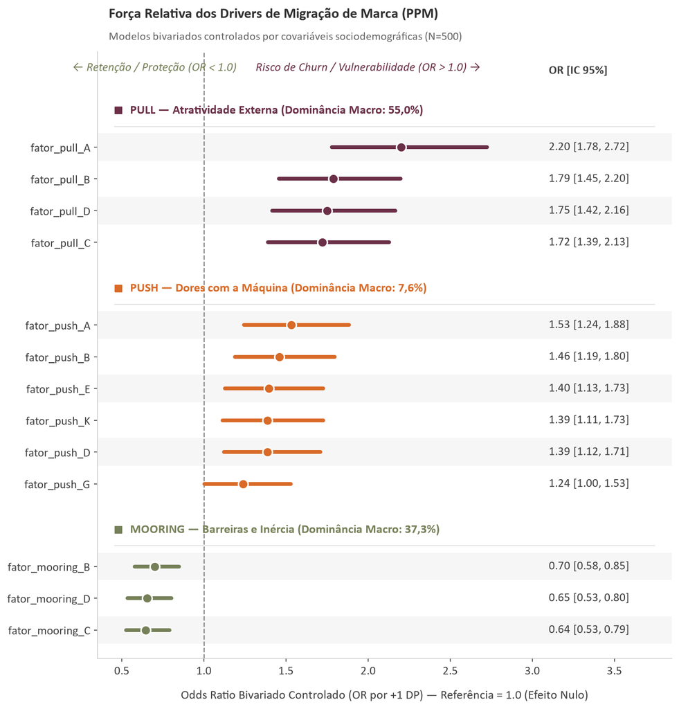

```python
import matplotlib.pyplot as plt
import numpy as np
import pandas as pd
from sklearn.preprocessing import StandardScaler
import statsmodels.api as sm

# Tipografia
plt.rcParams['font.sans-serif'] = 'Calibri'
plt.rcParams['font.family'] = 'sans-serif'

# 1. Configuração dos Controles e Dados
df = pd.read_csv('dados_ppm_portfolio.csv')
controles = ['z_idade', 'z_renda', 'z_tempo_posse']
y = df['Y_estagio1']

# Paleta do seu site
cores_outonais = {
    'PULL': '#6B3047',  # Roxo Bordô
    'PUSH': '#D96A27',  # Laranja Cobre
    'MOORING': '#768058',  # Verde Oliva
}

titulos_blocos = {
    'PULL': 'PULL — Atratividade Externa (Dominância Macro: 55,0%)',
    'PUSH': 'PUSH — Dores com a Máquina (Dominância Macro: 7,6%)',
    'MOORING': 'MOORING — Barreiras e Inércia (Dominância Macro: 37,3%)',
}

todos_itens = (
    [('MOORING', f'fator_mooring_{l}') for l in ['A', 'B', 'C', 'D']]
    + [
        ('PUSH', f'fator_push_{l}')
        for l in ['A', 'B', 'C', 'D', 'E', 'F', 'G', 'H', 'I', 'J', 'K', 'L']
    ]
    + [('PULL', f'fator_pull_{l}') for l in ['A', 'B', 'C', 'D']]
)

# 2. Filtragem de Itens Significativos (p < 0.05) com ORs Reais
linhas_plot = []
for bloco, item in todos_itens:
  z_item = StandardScaler().fit_transform(df[[item]]).flatten()
  df_temp = df[controles].copy()
  df_temp['z_var'] = z_item

  X = sm.add_constant(df_temp)
  mod = sm.Logit(y, X).fit(disp=False)

  pval = mod.pvalues['z_var']
  if pval < 0.05:
    coef = mod.params['z_var']
    or_val = np.exp(coef)
    ci_low = np.exp(mod.conf_int().loc['z_var', 0])
    ci_upp = np.exp(mod.conf_int().loc['z_var', 1])
    linhas_plot.append({
        'Pilar': bloco,
        'Item': item,
        'OR': or_val,
        'CI_Low': ci_low,
        'CI_Upp': ci_upp,
        'p_valor': pval,
        'Cor': cores_outonais[bloco],
    })

df_plot = pd.DataFrame(linhas_plot)

# 3. Construção do Layout por Blocos com Gaps e Posições Y
ordem_blocos = ['MOORING', 'PUSH', 'PULL']

y_pos_list = []
header_info = []
y_current = 0.5
row_counter = 0

for bloco in ordem_blocos:
  df_b = df_plot[df_plot['Pilar'] == bloco].sort_values(by='OR', ascending=True)

  for idx, row in df_b.iterrows():
    df_plot.loc[idx, 'y_pos'] = y_current
    df_plot.loc[idx, 'row_idx'] = row_counter
    y_pos_list.append((y_current, row['Item']))
    y_current += 1.0
    row_counter += 1

  # Posição do cabeçalho logo acima do grupo de itens
  header_y = y_current + 0.15
  header_info.append((header_y, titulos_blocos[bloco], cores_outonais[bloco]))
  y_current += 1.6  # Gap generoso entre blocos

# 4. Construção da Figura
fig, ax = plt.subplots(figsize=(11.8, 10.2), dpi=150)

# Linha vertical de referência (Efeito Nulo: OR = 1.0)
ax.axvline(1.0, color='#888888', linestyle='--', linewidth=1.2, zorder=1)

# Zebrado sutil intercalado de fundo para facilitar rastreamento horizontal
for _, row in df_plot.iterrows():
  y_val = row['y_pos']
  if int(row['row_idx']) % 2 == 0:
    ax.axhspan(y_val - 0.42, y_val + 0.42, color='#f6f6f7', zorder=0)

# Plotagem dos itens (barras arredondadas e pontos centrais)
for _, row in df_plot.iterrows():
  y_val = row['y_pos']
  cor = row['Cor']
  or_val = row['OR']
  ci_l = row['CI_Low']
  ci_u = row['CI_Upp']

  # Barra horizontal arredondada (IC 95% Real)
  ax.plot(
      [ci_l, ci_u],
      [y_val, y_val],
      color=cor,
      linewidth=3.8,
      solid_capstyle='round',
      zorder=2,
  )
  # Ponto central do OR
  ax.scatter(
      or_val,
      y_val,
      color=cor,
      s=95,
      zorder=3,
      edgecolors='white',
      linewidth=1.5,
  )

  # Rótulo numérico à direita (fonte 12)
  texto_ic = f'{or_val:.2f} [{ci_l:.2f}, {ci_u:.2f}]'
  ax.text(
      3.10,
      y_val,
      texto_ic,
      va='center',
      ha='left',
      fontsize=12,
      color='#404040',
      zorder=10,
      clip_on=False,
  )

# Cabeçalhos dos Blocos com Shapley (com recuo à esquerda e marcador de cor)
for hy, texto_h, cor_h in header_info:
  ax.scatter(0.48, hy, color=cor_h, s=50, marker='s', zorder=10)
  ax.text(
      0.55,
      hy,
      texto_h,
      fontsize=12.5,
      fontweight='bold',
      color=cor_h,
      va='center',
      ha='left',
      zorder=10,
      clip_on=False,
  )
  ax.axhline(
      hy - 0.50,
      color='#e2e2e4',
      linestyle='-',
      linewidth=0.9,
      xmin=0.03,
      xmax=0.97,
      zorder=1,
  )

# Linha de metadados do topo
y_top_header = y_current - 0.2

# 1. Cabeçalho da coluna de dados à direita
ax.text(
    3.10,
    y_top_header,
    'OR [IC 95%]',
    fontsize=12,
    fontweight='bold',
    color='#404040',
    va='center',
    ha='left',
    zorder=10,
    clip_on=False,
)

# 2. Indicadores conceituais dos quadrantes
ax.text(
    0.70,
    y_top_header,
    '← Retenção / Proteção (OR < 1.0)',
    ha='center',
    fontsize=12,
    color=cores_outonais['MOORING'],
    fontstyle='italic',
    zorder=10,
    clip_on=False,
)
ax.text(
    2.00,
    y_top_header,
    'Risco de Churn / Vulnerabilidade (OR > 1.0) →',
    ha='center',
    fontsize=12,
    color=cores_outonais['PULL'],
    fontstyle='italic',
    zorder=10,
    clip_on=False,
)

# Título e Subtítulo
ax.text(
    0.02,
    1.05,
    'Força Relativa dos Drivers de Migração de Marca (PPM)',
    transform=ax.transAxes,
    fontsize=14.5,
    fontweight='bold',
    color='#303030',
    ha='left',
    va='bottom',
    zorder=10,
)
ax.text(
    0.02,
    1.015,
    'Modelos bivariados controlados por covariáveis sociodemográficas (N=500)',
    transform=ax.transAxes,
    fontsize=11.5,
    color='#666666',
    ha='left',
    va='bottom',
    zorder=10,
)

# Formatação dos Eixos e Ticks (todos >= 12)
y_ticks = [y for y, label in y_pos_list]
y_labels = [label for y, label in y_pos_list]
ax.set_yticks(y_ticks)
ax.set_yticklabels(y_labels, fontsize=12, color='#404040')

ax.set_xlabel(
    'Odds Ratio Bivariado Controlado (OR por +1 DP) — Referência = 1.0 (Efeito'
    ' Nulo)',
    fontsize=12.5,
    color='#404040',
    labelpad=12,
)
ax.set_xlim(0.35, 3.85)
ax.set_ylim(-0.4, y_current + 0.4)

# Limpeza estética
for s in ['top', 'right']:
  ax.spines[s].set_visible(False)
ax.spines['left'].set_color('#cecece')
ax.spines['bottom'].set_color('#cecece')
ax.tick_params(colors='#404040', which='both', labelsize=12)

plt.subplots_adjust(left=0.18, right=0.86, top=0.91, bottom=0.08)
plt.show()
```